# Results

# Get map borders

```r
height <- max(manhattan_ll$lat) - min(manhattan_ll$lat)
width <- max(manhattan_ll$lon) - min(manhattan_ll$lon)
borders <- c(bottom  = min(manhattan_ll$lat)  - 0.2 * height,
             top     = max(manhattan_ll$lat)  + 0.2 * height,
             left    = min(manhattan_ll$lon) - 0.2 * width,
             right   = max(manhattan_ll$lon) + 0.2 * width)
borders
```

```
##    bottom       top      left     right
##  40.67401  40.91134 -74.03133 -73.88918
```

# Map actual (scaled) sale prices

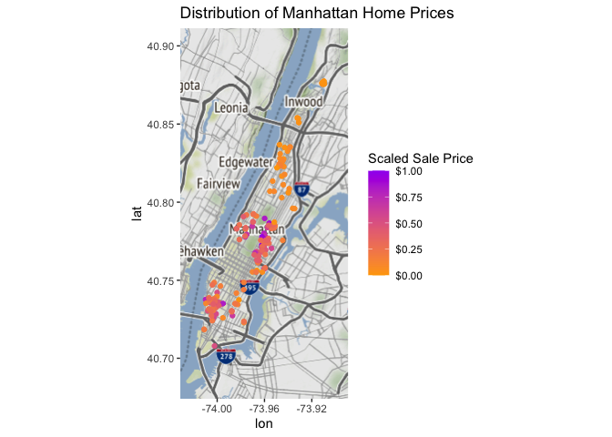

```r
map <- get_stamenmap(borders, zoom = 11, maptype = "terrain")

actual_map <- ggmap(map) +
  geom_point(data = manhattan_ll, mapping = aes(x = lon, y = lat, col = SALE.PRICE)) +
  scale_color_gradient("Scaled Sale Price",
                       low = "orange",
                       high = "purple",
                       labels = scales::dollar_format(prefix = "$")) +
  labs(title = "Distribution of Manhattan Home Prices")

actual_map
```

# Map GBM predictions

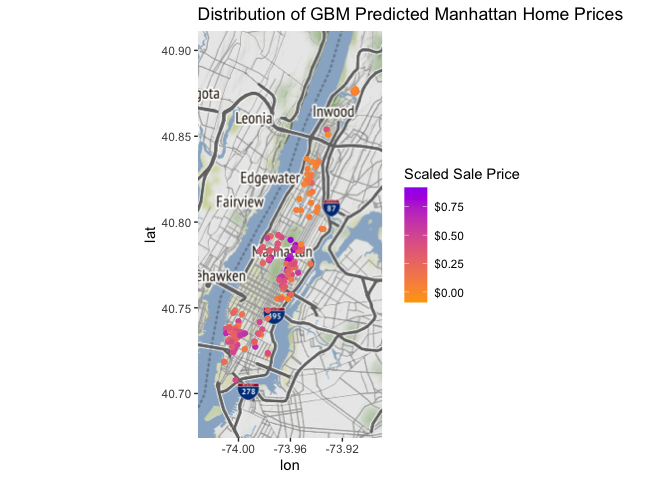

```r
gbm_map<- ggmap(map) +
  geom_point(data = manhattan_ll, mapping = aes(x = lon, y = lat, col = gbm_predicted)) +
  scale_color_gradient("Scaled Sale Price",
                       low = "orange",
                       high = "purple",
                       labels = scales::dollar_format(prefix = "$")) +
  labs(title = "Distribution of GBM Predicted Manhattan Home Prices")
gbm_map
```

# Side-by-side

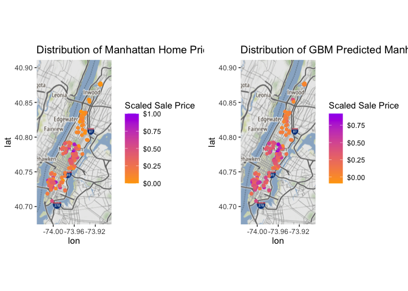

```r
grid.arrange(actual_map, gbm_map, nrow = 1)
```

# A closer look: Upper Manhattan

Since I scaled neighborhood_ord, the original values do not hold. Nevertheless, there are still 15 unique values and once I sort them, I can use my original scaling from part 1 (data cleaning) to determine which scaled value is associated with which neighborhood

```r
ord_values <- sort(unique(manhattan_ll$neighborhood_ord))
ord_values
```

```
##  [1] 0.00000000 0.07142857 0.14285714 0.21428571 0.28571429 0.35714286
##  [7] 0.42857143 0.50000000 0.57142857 0.64285714 0.71428571 0.78571429
## [13] 0.85714286 0.92857143 1.00000000
```

## Filter for upper manhattan homes

```r
upper_m <- manhattan_ll[manhattan_ll$neighborhood_ord %in% ord_values[c(1, 3:6, 8, 15)],]
```

```r
upper_m$SALE.PRICE <- as.character(round(upper_m$SALE.PRICE, 4))
upper_m$gbm_predicted <- as.character(round(upper_m$gbm_predicted, 4))

upper_m_popups <- paste0("Actual $", upper_m$SALE.PRICE, " vs. Predicted $", upper_m$gbm_predicted)
```

## Map it!

```r
house_icon <- makeIcon(iconUrl = "https://github.com/lcao21/GIS3_Final_Project/raw/master/Data/sale.png", iconWidth = 20*215/230, iconHeight = 20, iconAnchorX = 20*215/230/2, iconAnchorY = 16)

upper_m_borders <- data.frame(lat = upper_m$lat, lng = upper_m$lon)

upper_m_borders %>%
  leaflet() %>%
  addTiles() %>%
  addProviderTiles(providers$Stamen.TonerLite) %>%
  addMarkers(icon = house_icon, popup = upper_m_popups)
```

[interactive chart not shown]

# All of Manhattan

```r
all_m <- manhattan_ll
all_m$SALE.PRICE <- as.character(round(all_m$SALE.PRICE, 4))
all_m$gbm_predicted <- as.character(round(all_m$gbm_predicted, 4))

all_m_popups <- paste0("Actual $", all_m$SALE.PRICE, " vs. Predicted $", all_m$gbm_predicted)
```

## Map it!

```r
house_icon <- makeIcon(iconUrl = "https://github.com/lcao21/GIS3_Final_Project/raw/master/Data/sale.png", iconWidth = 20*215/230, iconHeight = 20, iconAnchorX = 20*215/230/2, iconAnchorY = 16)

all_m_borders <- data.frame(lat = all_m$lat, lng = all_m$lon)

all_m_borders %>%
  leaflet() %>%
  addTiles() %>%
  addProviderTiles(providers$Stamen.Terrain) %>%
  addMarkers(icon = house_icon, popup = all_m_popups)
```

[interactive chart not shown]

# Map neighborhoods by average difference in actual vs. predicted

## Create a column of absolute differences

```r
manhattan_ll$diff <- abs(manhattan_ll$gbm_predicted - manhattan_ll$SALE.PRICE)
manhattan_ll <- manhattan_ll %>%
  select("diff", everything())
```

## Find mean absolute difference/error for each neighborhood

```r
maes <- aggregate(manhattan_ll[, 1], list(manhattan_ll$neighborhood_ord), mean)
names(maes)[names(maes)=="Group.1"] <- "neighborhood_ord"
names(maes)[names(maes)=="x"] <- "MAE"
```

## Merge with manhattan_ll

```r
manhattan_maes <- merge(manhattan_ll, maes, all.x = TRUE)
manhattan_maes  <- manhattan_maes  %>%
  select("MAE", everything())
```

## Map of homes by differences

[figure not shown]

```r
ggmap(map) +
  geom_point(data = manhattan_maes, mapping = aes(x = lon, y = lat, col = diff)) +
  scale_color_gradient("|Predicted-Actual|",
                       low = "cadetblue4",
                       high = "cadetblue1",
                       labels = scales::dollar_format(prefix = "$")) +
  labs(title = "Distribution of Differences")
```

## Map of neighborhoods by MAE

I read in a shapefile of NYC neighborhoods and prepped it for st_intersection().

```r
neighborhoods <- st_read("desktop/GIS Proj/NTA/NTA.shp")
m_neighs <- neighborhoods[neighborhoods$boro_name %in% "Manhattan",]
st_crs(m_neighs) = 4326
formattable(as.data.frame(head(m_neighs)))
```

|  | boro_code | boro_name | county_fip | ntacode | ntaname | shape_area | shape_leng | geometry |
| --- | --- | --- | --- | --- | --- | --- | --- | --- |
| 5 | 1 | Manhattan | 061 | MN06 | Manhattanville | 10647078 | 17040.69 | MULTIPOLYGON (((-73.94608 4… |
| 52 | 1 | Manhattan | 061 | MN15 | Clinton | 18362149 | 34481.63 | MULTIPOLYGON (((-73.99383 4… |
| 79 | 1 | Manhattan | 061 | MN27 | Chinatown | 14501868 | 20786.26 | MULTIPOLYGON (((-73.98382 4… |
| 81 | 1 | Manhattan | 061 | MN25 | Battery Park City-Lower Manhattan | 19014299 | 43738.50 | MULTIPOLYGON (((-74.00078 4… |
| 83 | 1 | Manhattan | 061 | MN14 | Lincoln Square | 15805586 | 19869.91 | MULTIPOLYGON (((-73.975 40…. |
| 84 | 1 | Manhattan | 061 | MN17 | Midtown-Midtown South | 30191534 | 27032.70 | MULTIPOLYGON (((-73.97301 4… |

Since I’m calculating the intersection between neighborhoods and homes, I have to also prep the manhattan_maes dataframe, of which I made a copy of to use. By calculating the intersections, I’m adhering to the neighborhood classifications from the shapefile, not the original 15 that I created since part 1. These new classifications, however, should not be that different or different at all.

## Calculate intersection

```r
maes_copy <- manhattan_maes
coordinates(maes_copy) <- c("lon", "lat")
proj4string(maes_copy) <- CRS("+init=epsg:4326")
maes_sf <- st_as_sf(maes_copy) %>% st_transform(4326)
inter <- as.data.frame(st_intersection(x = m_neighs, y = maes_sf))

formattable(head(inter))
```

|  | boro_code | boro_name | county_fip | ntacode | ntaname | shape_area | shape_leng | MAE | neighborhood_ord | diff | gbm_predicted | SALE.PRICE | num_schools | num_food | num_parks | num_subway | RESIDENTIAL.UNITS | LAND.SQUARE.FEET | ADDRESS | geometry |
| --- | --- | --- | --- | --- | --- | --- | --- | --- | --- | --- | --- | --- | --- | --- | --- | --- | --- | --- | --- | --- |
| 167 | 1 | Manhattan | 061 | MN33 | East Harlem South | 16650688 | 18624.66 | 0.023044217 | 0.00000000 | 0.007292702 | 0.03208544 | 0.02479273 | 0.0 | 0.66666667 | 0.3050847 | 0.1666667 | 0.5 | 0.1639249 | 1255 PARK AVENUE, Manhattan | POINT (-73.95172 40.7872) |
| 180 | 1 | Manhattan | 061 | MN34 | East Harlem North | 24494898 | 30603.72 | 0.023044217 | 0.00000000 | 0.049181981 | 0.11381744 | 0.06463546 | 0.3 | 1.00000000 | 0.6101695 | 0.0000000 | 0.5 | 0.3255274 | 350 EAST 116TH STREET, Manhattan | POINT (-73.93612 40.79607) |
| 180.1 | 1 | Manhattan | 061 | MN34 | East Harlem North | 24494898 | 30603.72 | 0.023044217 | 0.00000000 | 0.012657969 | 0.08996203 | 0.07730406 | 0.3 | 0.73333333 | 0.5762712 | 0.0000000 | 1.0 | 0.4296497 | 415 EAST 116TH ST, Manhattan | POINT (-73.93452 40.79587) |
| 81 | 1 | Manhattan | 061 | MN25 | Battery Park City-Lower Manhattan | 19014299 | 43738.50 | 0.048060430 | 0.07142857 | 0.048060430 | 0.45786440 | 0.50592483 | 0.4 | 0.06666667 | 0.2372881 | 0.1666667 | 0.5 | 0.5457712 | 245 WATER STREET, Manhattan | POINT (-74.00226 40.70791) |
| 164 | 1 | Manhattan | 061 | MN36 | Washington Heights South | 23092824 | 22106.42 | 0.009533167 | 0.14285714 | 0.003928350 | 0.02270133 | 0.02662968 | 0.1 | 0.00000000 | 0.4576271 | 0.3333333 | 0.0 | 0.2901103 | 565 WEST 159TH STREET, Manhattan | POINT (-73.94297 40.83505) |
| 164.1 | 1 | Manhattan | 061 | MN36 | Washington Heights South | 23092824 | 22106.42 | 0.009533167 | 0.14285714 | 0.007583534 | 0.03526893 | 0.02768540 | 0.0 | 0.00000000 | 0.5254237 | 0.1666667 | 0.5 | 0.8399458 | 857 RIVERSIDE DRIVE, Manhattan | POINT (-73.94726 40.83676) |

The intersection dataframe only gave me point geometries, but I want multipolygons from the original shapefile. So I merged the two:

## Merge

```r
inter_poly <- merge(inter, m_neighs, by = "ntaname", all.x = TRUE)
inter_poly <- inter_poly[c(1,8,10:12,20,25:27)]

formattable(head(inter_poly))
```

| ntaname | MAE | diff | gbm_predicted | SALE.PRICE | geometry.x | shape_area.y | shape_leng.y | geometry.y |
| --- | --- | --- | --- | --- | --- | --- | --- | --- |
| Battery Park City-Lower Manhattan | 0.04806043 | 0.048060430 | 0.45786440 | 0.50592483 | POINT (-74.00226 40.70791) | 19014299 | 43738.50 | MULTIPOLYGON (((-74.00078 4… |
| Central Harlem North-Polo Grounds | 0.03396124 | 0.019306857 | 0.06433150 | 0.08363835 | POINT (-73.94412 40.81115) | 25403484 | 27983.88 | MULTIPOLYGON (((-73.93445 4… |
| Central Harlem North-Polo Grounds | 0.03396124 | 0.012461115 | 0.01944715 | 0.03190826 | POINT (-73.94529 40.81666) | 25403484 | 27983.88 | MULTIPOLYGON (((-73.93445 4… |
| Central Harlem North-Polo Grounds | 0.03396124 | 0.010227151 | 0.10547838 | 0.09525123 | POINT (-73.94303 40.81773) | 25403484 | 27983.88 | MULTIPOLYGON (((-73.93445 4… |
| Central Harlem North-Polo Grounds | 0.03396124 | 0.014729070 | 0.06745240 | 0.08218147 | POINT (-73.93907 40.8086) | 25403484 | 27983.88 | MULTIPOLYGON (((-73.93445 4… |
| Central Harlem South | 0.03396124 | 0.001242191 | 0.06233756 | 0.06357975 | POINT (-73.9454 40.8029) | 14439305 | 16621.02 | MULTIPOLYGON (((-73.94177 4… |

## Map it!

```r
inter_poly <- as(st_as_sf(inter_poly), "Spatial")

tmap_mode("view")
tm_basemap("Stamen.TonerLite") +
  tm_shape(inter_poly) +
  tm_polygons("MAE", palette = "viridis") +
  tm_tiles("Stamen.TonerLabels")
```

[interactive chart not shown]

## Neighborhood breakdown

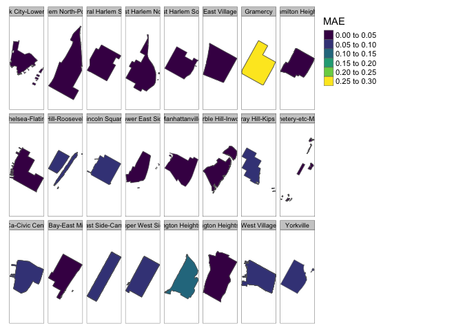

```r
tmap_mode("plot")
tm_shape(inter_poly) +
  tm_polygons("MAE", palette = "viridis") +
  tm_facets(by = "ntaname")
```

# Other visualizations

## Density map

[figure not shown]

```r
ggmap(map) +
  stat_density2d(aes(x=lon, y=lat, fill=..level..), data = manhattan_maes, geom="polygon", alpha = .2) +
  geom_density_2d(aes(x=lon, y=lat), data=manhattan_maes, colour = "white", alpha = .4)
```

Next, I want to make a series of maps that show each neighborhood’s average sale price in relation to each of the 7 important independent variables. First, I have to create a dataframe of the average prices by neighborhood and can do so by aggregating inter_poly then merging it with the neighborhoods shapefile.

```r
manhattan_maes_sf <- st_as_sf(manhattan_maes, coords=c("lon","lat"),
                              crs=4326)

mean_price_neigh <- aggregate(inter_poly$SALE.PRICE, list(inter_poly$ntaname), mean)
mean_price_neigh <- merge(mean_price_neigh, neighborhoods, by.x="Group.1", by.y="ntaname")
mean_price_neigh <- mean_price_neigh[c(1,2,7:9)]
colnames(mean_price_neigh) <- c("Neighborhood", "Avg. Sale Price", "shape_area", "shape_leng", "geometry")
formattable(head(mean_price_neigh))
```

| Neighborhood | Avg. Sale Price | shape_area | shape_leng | geometry |
| --- | --- | --- | --- | --- |
| Battery Park City-Lower Manhattan | 0.50592483 | 19014299 | 43738.50 | MULTIPOLYGON (((-74.00078 4… |
| Central Harlem North-Polo Grounds | 0.07324483 | 25403484 | 27983.88 | MULTIPOLYGON (((-73.93445 4… |
| Central Harlem South | 0.08070804 | 14439305 | 16621.02 | MULTIPOLYGON (((-73.94177 4… |
| East Harlem North | 0.05557380 | 24494898 | 30603.72 | MULTIPOLYGON (((-73.92719 4… |
| East Harlem South | 0.02479273 | 16650688 | 18624.66 | MULTIPOLYGON (((-73.93505 4… |
| East Village | 0.36102778 | 10894316 | 13555.24 | MULTIPOLYGON (((-73.98256 4… |

## Map of neighborhoods by average sale price and homes by num_schools (# schools in 1 mile buffer)

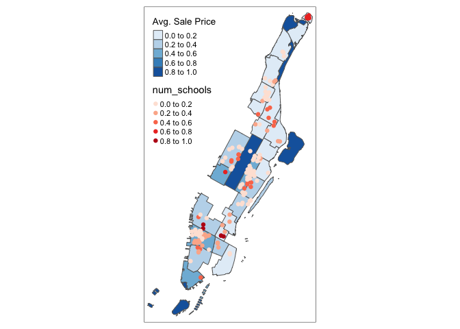

```r
mean_price_neigh_sf <- st_as_sf(mean_price_neigh)
st_crs(mean_price_neigh_sf) <- 4326

tm_shape(mean_price_neigh_sf) +
  tm_polygons("Avg. Sale Price", palette = "Blues") +
tm_shape(manhattan_maes_sf) +
  tm_dots("num_schools", palette = "Reds", size=0.2)
```

## Map of neighborhoods by average sale price and homes by num_food (# food vendors in 1 mile buffer)

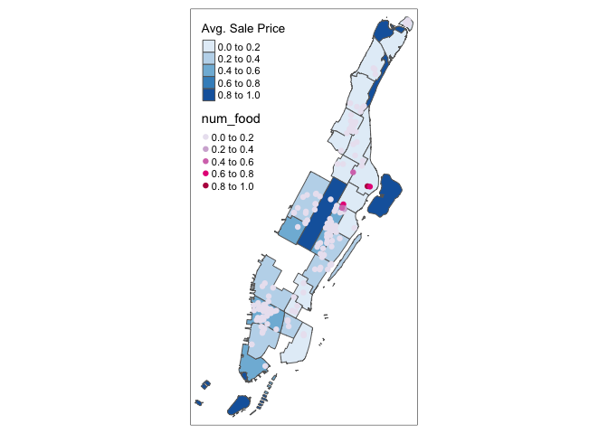

```r
tm_shape(mean_price_neigh_sf) +
  tm_polygons("Avg. Sale Price", palette = "Blues") +
tm_shape(manhattan_maes_sf) +
  tm_dots("num_food", palette = "PuRd", size=0.2)
```

## Map of neighborhoods by average sale price and homes by num_parks (# parks in 1 mile buffer)

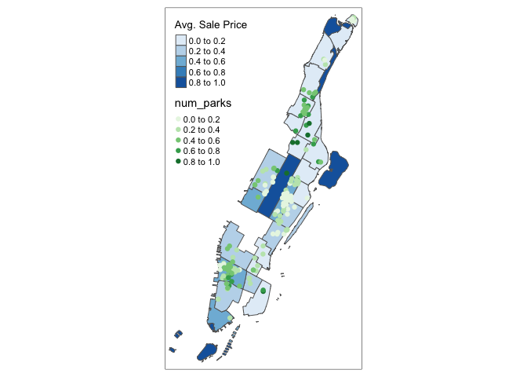

```r
tm_shape(mean_price_neigh_sf) +
  tm_polygons("Avg. Sale Price", palette = "Blues") +
tm_shape(manhattan_maes_sf) +
  tm_dots("num_parks", palette = "Greens", size=0.2)
```

## Map of neighborhoods by average sale price and homes by num_subway (# subway stations in 1 mile buffer)

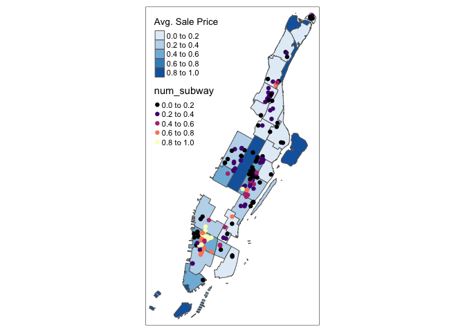

```r
tm_shape(mean_price_neigh_sf) +
  tm_polygons("Avg. Sale Price", palette = "Blues") +
tm_shape(manhattan_maes_sf) +
  tm_dots("num_subway", palette = "magma", size=0.2)
```

## Map of neighborhoods by average sale price and homes by RESIDENTIAL.UNITS

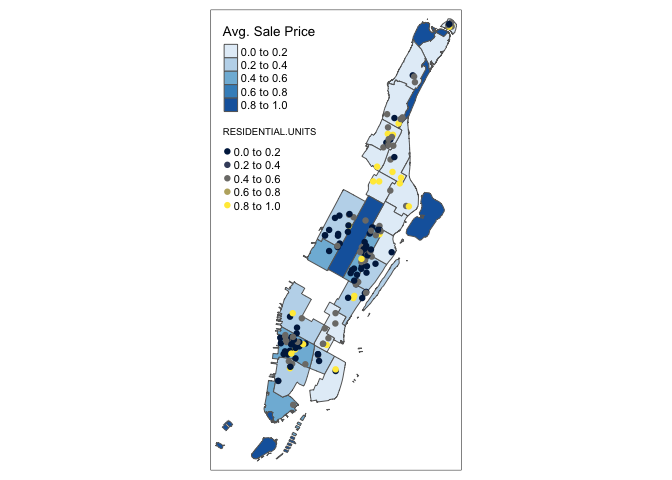

```r
tm_shape(mean_price_neigh_sf) +
  tm_polygons("Avg. Sale Price", palette = "Blues") +
tm_shape(manhattan_maes_sf) +
  tm_dots("RESIDENTIAL.UNITS", palette = "cividis", size=0.2)
```

## Map of neighborhoods by average sale price and homes by LAND.SQUARE.FEET

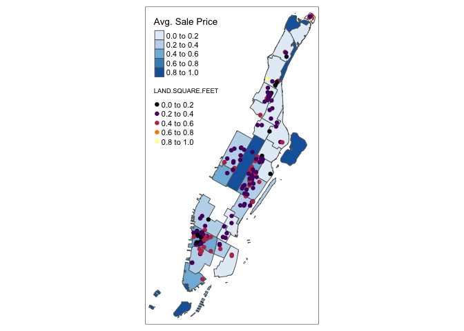

```r
tm_shape(mean_price_neigh_sf) +
  tm_polygons("Avg. Sale Price", palette = "Blues") +
tm_shape(manhattan_maes_sf) +
  tm_dots("LAND.SQUARE.FEET", palette = "inferno", size=0.2)
```

Interestingly, homes in neighborhoods with the heightest average sale prices don’t have the highest values in for these independent variables. Rather, it seems that homes with the highest values are located in neighborhoods with the median to low average sale prices.